# Power plant Descriptive Analysis

Roqeeb Olaniyi

14/06/2021

### Objective of analysis

The power plant analysis was performed to answer the task questions below

- What is the mean value of daily yield?
- What is the total irradiation per day?
- What is the max ambient and module temperature?
- How many inverters are there for each plant?
- What is the maximum/minimum amount of DC/AC Power generated in a time interval/day?
- Which inverter (source_key) has produced maximum DC/AC power?
- Rank the inverters based on the DC/AC power they produce
- Is there any missing data?

Loading the libraries to be used for the analysis

```r
library(tidyverse)
```

```r
library(ggplot2)
library(lubridate)
```

Reading the csv files to be used for the analysis

```r
plant_1_gen <- read_csv("C:/Users/ayoro/Desktop/Datasci/Case studies/Power plant/Plant_1_Generation_Data.csv")
plant_2_gen <- read_csv("C:/Users/ayoro/Desktop/Datasci/Case studies/Power plant/Plant_2_Generation_Data.csv")
plant_1_weather <- read_csv("C:/Users/ayoro/Desktop/Datasci/Case studies/Power plant/Plant_1_Weather_Sensor_Data.csv")
plant_2_weather <- read_csv("C:/Users/ayoro/Desktop/Datasci/Case studies/Power plant/Plant_2_Weather_Sensor_Data.csv")
```

Initial data exploration

```r
head(plant_1_gen)
```

```
## # A tibble: 6 x 7
##   DATE_TIME      PLANT_ID SOURCE_KEY   DC_POWER AC_POWER DAILY_YIELD TOTAL_YIELD
##   <chr>             <dbl> <chr>           <dbl>    <dbl>       <dbl>       <dbl>
## 1 15-05-2020 00~  4135001 1BY6WEcLGh8~        0        0           0     6259559
## 2 15-05-2020 00~  4135001 1IF53ai7Xc0~        0        0           0     6183645
## 3 15-05-2020 00~  4135001 3PZuoBAID5W~        0        0           0     6987759
## 4 15-05-2020 00~  4135001 7JYdWkrLSPk~        0        0           0     7602960
## 5 15-05-2020 00~  4135001 McdE0feGgRq~        0        0           0     7158964
## 6 15-05-2020 00~  4135001 VHMLBKoKgIr~        0        0           0     7206408
```

```r
glimpse(plant_1_gen)
```

```
## Rows: 68,778
## Columns: 7
## $ DATE_TIME   <chr> "15-05-2020 00:00", "15-05-2020 00:00", "15-05-2020 00:00"~
## $ PLANT_ID    <dbl> 4135001, 4135001, 4135001, 4135001, 4135001, 4135001, 4135~
## $ SOURCE_KEY  <chr> "1BY6WEcLGh8j5v7", "1IF53ai7Xc0U56Y", "3PZuoBAID5Wc2HD", "~
## $ DC_POWER    <dbl> 0, 0, 0, 0, 0, 0, 0, 0, 0, 0, 0, 0, 0, 0, 0, 0, 0, 0, 0, 0~
## $ AC_POWER    <dbl> 0, 0, 0, 0, 0, 0, 0, 0, 0, 0, 0, 0, 0, 0, 0, 0, 0, 0, 0, 0~
## $ DAILY_YIELD <dbl> 0, 0, 0, 0, 0, 0, 0, 0, 0, 0, 0, 0, 0, 0, 0, 0, 0, 0, 0, 0~
## $ TOTAL_YIELD <dbl> 6259559, 6183645, 6987759, 7602960, 7158964, 7206408, 7028~
```

```r
glimpse(plant_2_gen)
```

```
## Rows: 67,698
## Columns: 7
## $ DATE_TIME   <dttm> 2020-05-15 00:00:00, 2020-05-15 00:00:00, 2020-05-15 00:0~
## $ PLANT_ID    <dbl> 4136001, 4136001, 4136001, 4136001, 4136001, 4136001, 4136~
## $ SOURCE_KEY  <chr> "4UPUqMRk7TRMgml", "81aHJ1q11NBPMrL", "9kRcWv60rDACzjR", "~
## $ DC_POWER    <dbl> 0, 0, 0, 0, 0, 0, 0, 0, 0, 0, 0, 0, 0, 0, 0, 0, 0, 0, 0, 0~
## $ AC_POWER    <dbl> 0, 0, 0, 0, 0, 0, 0, 0, 0, 0, 0, 0, 0, 0, 0, 0, 0, 0, 0, 0~
## $ DAILY_YIELD <dbl> 9425.0000, 0.0000, 3075.3333, 269.9333, 3177.0000, 1872.50~
## $ TOTAL_YIELD <dbl> 2429011, 1215278736, 2247719577, 1704250, 19941526, 179495~
```

```r
head(plant_1_weather)
```

```
## # A tibble: 6 x 6
##   DATE_TIME           PLANT_ID SOURCE_KEY    AMBIENT_TEMPERAT~ MODULE_TEMPERATU~
##   <dttm>                 <dbl> <chr>                     <dbl>             <dbl>
## 1 2020-05-15 00:00:00  4135001 HmiyD2TTLFNq~              25.2              22.9
## 2 2020-05-15 00:15:00  4135001 HmiyD2TTLFNq~              25.1              22.8
## 3 2020-05-15 00:30:00  4135001 HmiyD2TTLFNq~              24.9              22.6
## 4 2020-05-15 00:45:00  4135001 HmiyD2TTLFNq~              24.8              22.4
## 5 2020-05-15 01:00:00  4135001 HmiyD2TTLFNq~              24.6              22.2
## 6 2020-05-15 01:15:00  4135001 HmiyD2TTLFNq~              24.5              22.0
## # ... with 1 more variable: IRRADIATION <dbl>
```

```r
glimpse(plant_1_weather)
```

```
## Rows: 3,182
## Columns: 6
## $ DATE_TIME           <dttm> 2020-05-15 00:00:00, 2020-05-15 00:15:00, 2020-05~
## $ PLANT_ID            <dbl> 4135001, 4135001, 4135001, 4135001, 4135001, 41350~
## $ SOURCE_KEY          <chr> "HmiyD2TTLFNqkNe", "HmiyD2TTLFNqkNe", "HmiyD2TTLFN~
## $ AMBIENT_TEMPERATURE <dbl> 25.18432, 25.08459, 24.93575, 24.84613, 24.62153, ~
## $ MODULE_TEMPERATURE  <dbl> 22.85751, 22.76167, 22.59231, 22.36085, 22.16542, ~
## $ IRRADIATION         <dbl> 0.0000000000, 0.0000000000, 0.0000000000, 0.000000~
```

```r
glimpse(plant_2_weather)
```

```
## Rows: 3,259
## Columns: 6
## $ DATE_TIME           <dttm> 2020-05-15 00:00:00, 2020-05-15 00:15:00, 2020-05~
## $ PLANT_ID            <dbl> 4136001, 4136001, 4136001, 4136001, 4136001, 41360~
## $ SOURCE_KEY          <chr> "iq8k7ZNt4Mwm3w0", "iq8k7ZNt4Mwm3w0", "iq8k7ZNt4Mw~
## $ AMBIENT_TEMPERATURE <dbl> 27.00476, 26.88081, 26.68206, 26.50059, 26.59615, ~
## $ MODULE_TEMPERATURE  <dbl> 25.06079, 24.42187, 24.42729, 24.42068, 25.08821, ~
## $ IRRADIATION         <dbl> 0.000000000, 0.000000000, 0.000000000, 0.000000000~
```

Checking for null or empty values in column of each dataframe

```r
colSums(is.na(plant_1_gen))
```

```
##   DATE_TIME    PLANT_ID  SOURCE_KEY    DC_POWER    AC_POWER DAILY_YIELD
##           0           0           0           0           0           0
## TOTAL_YIELD
##           0
```

```r
colSums(is.na(plant_2_gen))
```

```
##   DATE_TIME    PLANT_ID  SOURCE_KEY    DC_POWER    AC_POWER DAILY_YIELD
##           0           0           0           0           0           0
## TOTAL_YIELD
##           0
```

```r
colSums(is.na(plant_1_weather))
```

```
##           DATE_TIME            PLANT_ID          SOURCE_KEY AMBIENT_TEMPERATURE
##                   0                   0                   0                   0
##  MODULE_TEMPERATURE         IRRADIATION
##                   0                   0
```

```r
colSums(is.na(plant_2_weather))
```

```
##           DATE_TIME            PLANT_ID          SOURCE_KEY AMBIENT_TEMPERATURE
##                   0                   0                   0                   0
##  MODULE_TEMPERATURE         IRRADIATION
##                   0                   0
```

Creating a date column from the date_time column to make analysis better

```r
plant_1_gen <- plant_1_gen %>%
                    mutate('date' = date(dmy_hm(DATE_TIME)))

plant_2_gen <- plant_2_gen %>%
                    mutate('date' = date(DATE_TIME))

plant_1_weather <- plant_1_weather %>%
                    mutate('date' = date(DATE_TIME))

plant_2_weather <- plant_2_weather %>%
                    mutate('date' = date(DATE_TIME))
```

Getting mean daily yield for each plant

```r
plant_1_gen %>%
summarise(mean = mean(DAILY_YIELD))
```

```
## # A tibble: 1 x 1
##    mean
##   <dbl>
## 1 3296.
```

```r
plant_2_gen %>%
summarise(mean = mean(DAILY_YIELD))
```

```
## # A tibble: 1 x 1
##    mean
##   <dbl>
## 1 3295.
```

#### Total irradiation per day

Plant 1

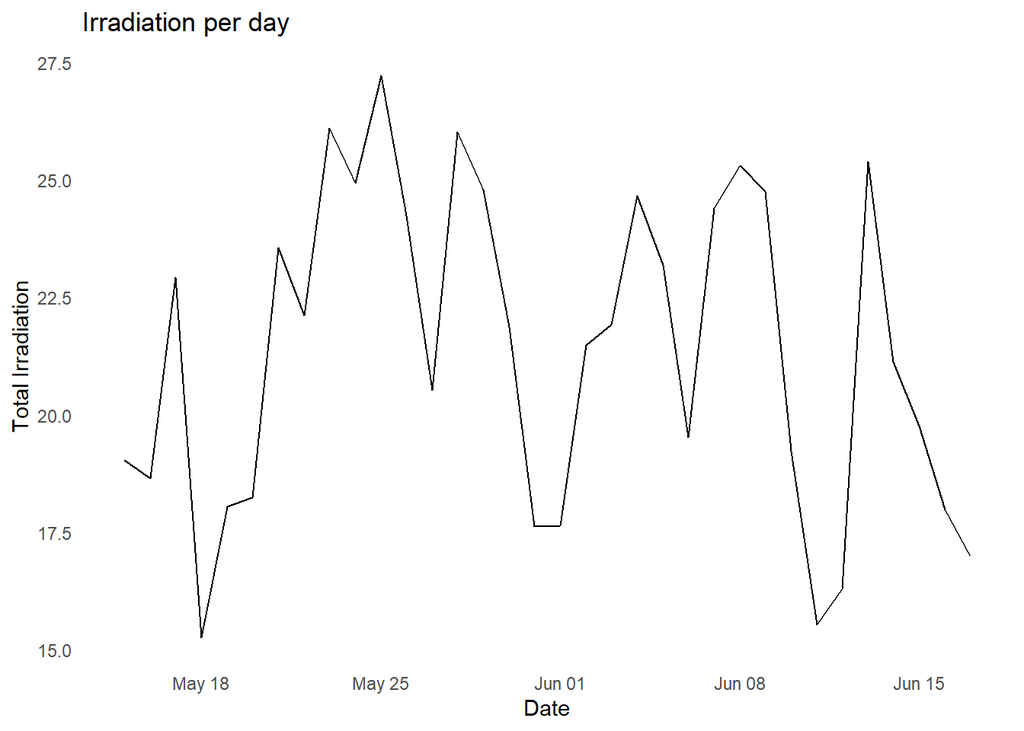

```r
plant_1_weather %>%
group_by(date) %>%
summarise('Total_irradiation' = sum(IRRADIATION)) %>%

  ggplot(aes(x = date, y = Total_irradiation)) +
  geom_line() +
  labs(title = 'Irradiation per day', y = 'Total Irradiation', x = 'Date') +
  theme_minimal() +
  theme(panel.grid = element_blank())
```

Plant 2

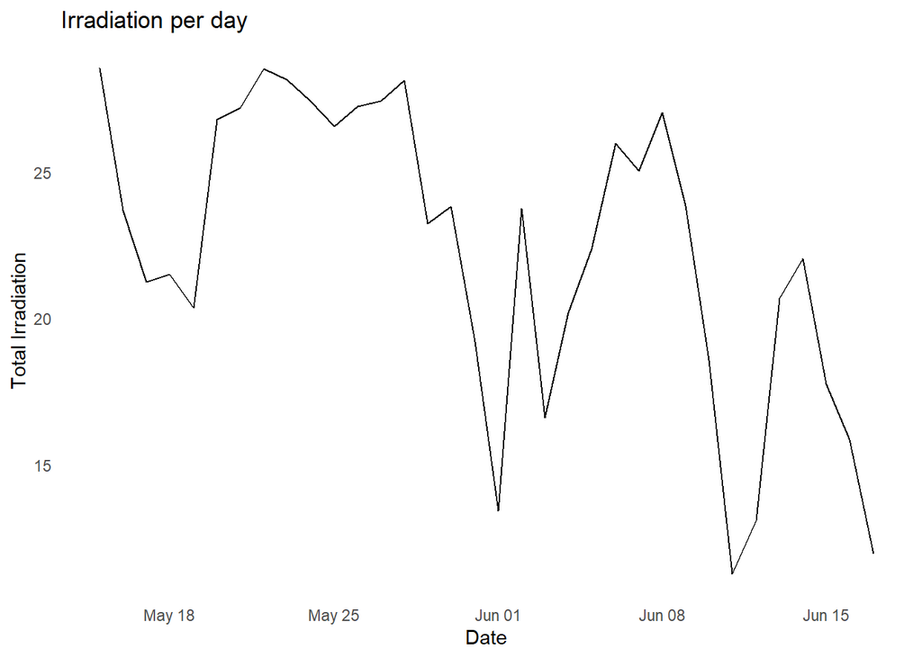

```r
plant_2_weather %>%
group_by(date) %>%
summarise('Total_irradiation' = sum(IRRADIATION)) %>%
  ggplot(aes(x = date, y = Total_irradiation)) +
  geom_line() +
  labs(title = 'Irradiation per day', y = 'Total Irradiation', x = 'Date') +
  theme_minimal() +
  theme(panel.grid = element_blank())
```

#### Max ambient and module temperature

Plant 1

```r
plant_1_weather %>%
summarise('max_ambient_temp' = max(AMBIENT_TEMPERATURE), 'max_module_temp' = max(MODULE_TEMPERATURE))
```

```
## # A tibble: 1 x 2
##   max_ambient_temp max_module_temp
##              <dbl>           <dbl>
## 1             35.3            65.5
```

Plant 2

```r
plant_2_weather %>%
summarise('max_ambient_temp' = max(AMBIENT_TEMPERATURE), 'max_module_temp' = max(MODULE_TEMPERATURE))
```

```
## # A tibble: 1 x 2
##   max_ambient_temp max_module_temp
##              <dbl>           <dbl>
## 1             39.2            66.6
```

#### Number of inverters

Plant 1

```r
plant_1_gen %>%
summarize('inverters' = n_distinct(SOURCE_KEY))
```

```
## # A tibble: 1 x 1
##   inverters
##       <int>
## 1        22
```

Plant 2

```r
plant_2_gen %>%
summarize('inverters' = n_distinct(SOURCE_KEY))
```

```
## # A tibble: 1 x 1
##   inverters
##       <int>
## 1        22
```

Plant 1

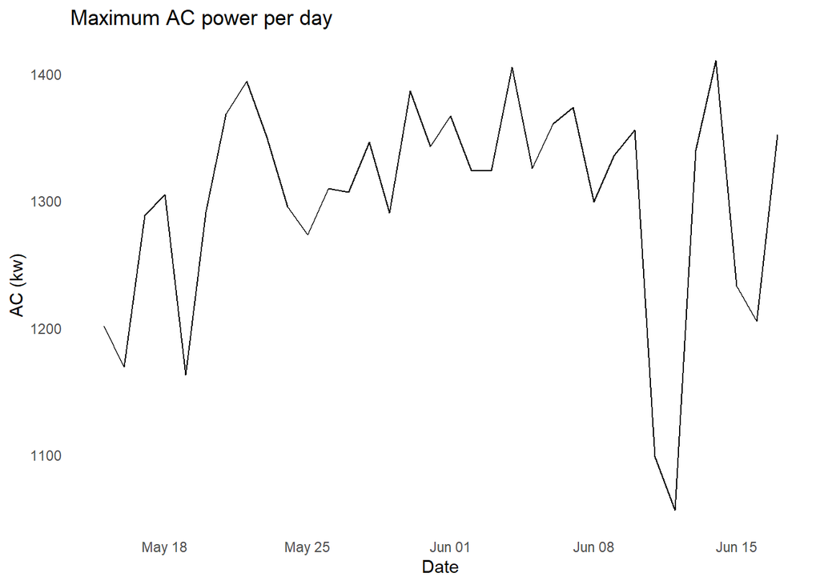

```r
max_AC_DC_1 <- plant_1_gen %>%
                group_by(date) %>%
                summarise('max_AC' = max(AC_POWER),
                'min_AC' = min(AC_POWER),
                'max_DC' = max(DC_POWER),
                'min_DC' = min(DC_POWER))

max_AC_DC_1 %>%
  ggplot(aes(x = date, y = max_AC)) +
  geom_line() +
  labs(title = 'Maximum AC power per day', x = 'Date', y = 'AC (kw)') +
  theme_minimal() +
  theme(panel.grid = element_blank())
```

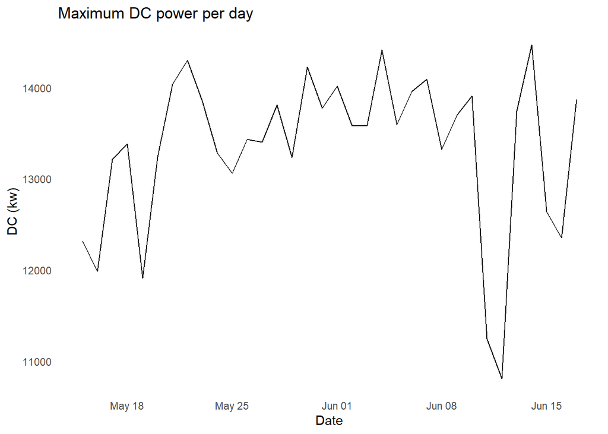

```r
max_AC_DC_1 %>%
  ggplot(aes(x = date, y = max_DC)) +
  geom_line()  +
  labs(title = 'Maximum DC power per day', x = 'Date', y = 'DC (kw)') +
  theme_minimal() +
  theme(panel.grid = element_blank())
```

Plant 2

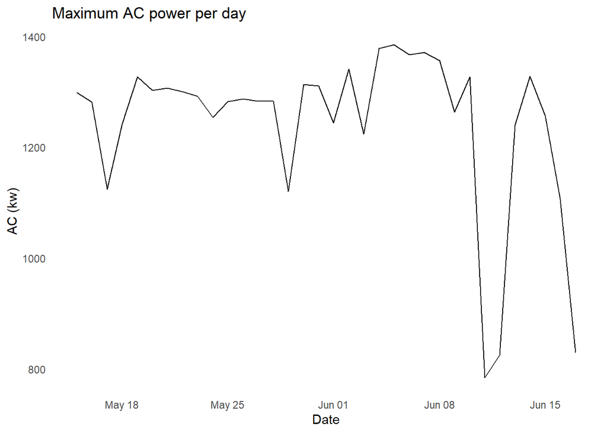

```r
max_AC_DC_2 <- plant_2_gen %>%
              group_by(date) %>%
              summarise('max_AC' = max(AC_POWER),
              'min_AC' = min(AC_POWER),
              'max_DC' = max(DC_POWER),
              'min_DC' = min(DC_POWER))
max_AC_DC_2 %>%
  ggplot(aes(x = date, y = max_AC)) +
  geom_line() +
  labs(title = 'Maximum AC power per day', x = 'Date', y = 'AC (kw)') +
  theme_minimal() +
  theme(panel.grid = element_blank())
```

[figure not shown]

```r
max_AC_DC_2 %>%
  ggplot(aes(x = date, y = max_AC)) +
  geom_line() +
  labs(title = 'Maximum DC power per day', x = 'Date', y = 'DC (kw)') +
  theme_minimal() +
  theme(panel.grid = element_blank())
```

#### Inverter with the maximum AC/DC power output

Plant 1

```r
plant_1_gen %>%
filter(AC_POWER == max(AC_POWER) | DC_POWER == max(DC_POWER)) %>%
select('max AC/DC inverter' = SOURCE_KEY)
```

```
## # A tibble: 1 x 1
##   `max AC/DC inverter`
##   <chr>
## 1 wCURE6d3bPkepu2
```

Plant 2

```r
plant_2_gen %>%
filter(AC_POWER == max(AC_POWER) | DC_POWER == max(DC_POWER)) %>%
select('max AC/DC inverter' = SOURCE_KEY)
```

```
## # A tibble: 1 x 1
##   `max AC/DC inverter`
##   <chr>
## 1 oZ35aAeoifZaQzV
```

#### Inverter rank based on AC/DC power output

Plant 1

```r
plant_1_gen %>%
group_by(SOURCE_KEY) %>%
select(SOURCE_KEY, AC_POWER, DC_POWER) %>%
summarise('AC_POWER' = sum(AC_POWER), 'DC_POWER' = sum(DC_POWER)) %>%
arrange(desc(AC_POWER, DC_POWER)) %>%
mutate('rank' = dense_rank(interaction(desc(AC_POWER),desc(DC_POWER)))) %>%
select(rank,SOURCE_KEY, AC_POWER, DC_POWER)
```

```
## # A tibble: 22 x 4
##     rank SOURCE_KEY      AC_POWER  DC_POWER
##    <int> <chr>              <dbl>     <dbl>
##  1     1 adLQvlD726eNBSB  997125. 10197782.
##  2     2 1IF53ai7Xc0U56Y  984007. 10062944.
##  3     3 VHMLBKoKgIrUVDU  983449. 10057251.
##  4     4 3PZuoBAID5Wc2HD  982068. 10043127.
##  5     5 McdE0feGgRqW7Ca  981081. 10032124.
##  6     6 ZnxXDlPa8U1GXgE  977644.  9997405.
##  7     7 iCRJl6heRkivqQ3  976688.  9987733.
##  8     8 uHbuxQJl8lW7ozc  976462.  9985363.
##  9     9 zVJPv84UY57bAof  973678.  9956927.
## 10    10 wCURE6d3bPkepu2  969260.  9911622.
## # ... with 12 more rows
```

Plant 2

```r
plant_2_gen %>%
group_by(SOURCE_KEY) %>%
select(SOURCE_KEY, AC_POWER, DC_POWER) %>%
summarise('AC_POWER' = sum(AC_POWER), 'DC_POWER' = sum(DC_POWER)) %>%
arrange(desc(AC_POWER, DC_POWER)) %>%
mutate('rank' = dense_rank(interaction(desc(AC_POWER),desc(DC_POWER)))) %>%
select(rank,SOURCE_KEY, AC_POWER, DC_POWER)
```

```
## # A tibble: 22 x 4
##     rank SOURCE_KEY      AC_POWER DC_POWER
##    <int> <chr>              <dbl>    <dbl>
##  1     1 Mx2yZCDsyf6DPfv  890317.  910617.
##  2     2 Qf4GUc1pJu5T6c6  870756.  890596.
##  3     3 4UPUqMRk7TRMgml  867688.  887445.
##  4     4 oZ35aAeoifZaQzV  865436.  885152.
##  5     5 V94E5Ben1TlhnDV  835444.  854376.
##  6     6 vOuJvMaM2sgwLmb  835012.  854173.
##  7     7 oZZkBaNadn6DNKz  815638.  834047.
##  8     8 PeE6FRyGXUgsRhN  792665.  810479.
##  9     9 LlT2YUhhzqhg5Sw  782522.  800063.
## 10    10 WcxssY2VbP4hApt  781609.  799350.
## # ... with 12 more rows
```